# Practical Machine Learning Final Project

redger

June 16, 2016

# 1 Executive Summary

The goal of this project was to use Machine Learning to investigate the tracking of exercise quality based on measurements taken by the type of devices widely available if wearable devices.  
Different Machine Learning algorithms were used to predict the outcomes for 20 observations with “unknown” outcomes. Training data was provided.  
Multiple models were considered, 3 were tried and 1 was selected as most appropriate. The Random Forest method produced a high quality result with an acceptable computational overhead. A small amount of refinement was performed to reduce the likelihood of overfitting - by selecting the highest importance (impact) predictors.

The final prediction for the 20 observations was scored 100% accurate by the Coursera grading software justifying the choice of the Random Forest approach.

# 2 Background

Using devices such as Jawbone Up, Nike FuelBand, and Fitbit it is now possible to collect a large amount of data about personal activity relatively inexpensively. These type of devices are part of the quantified self movement – a group of enthusiasts who take measurements about themselves regularly to improve their health, to find patterns in their behavior, or because they are tech geeks. One thing that people regularly do is quantify how much of a particular activity they do, but they rarely quantify how well they do it. In this project, our goal was to use data from accelerometers on the belt, forearm, arm, and dumbell to predict exercise quality. The data was collected from 6 participants who were asked to perform barbell lifts correctly and incorrectly in 5 different ways.

# 3 Data Exploration

```
## [1] "The Training dataset dimensions are:"
```

```
## [1] 19622   160
```

```
## [1] "More detailed inspection of the Training dataset"
```

```
## 'data.frame':    19622 obs. of  20 variables:
##  $ X                   : int  1 2 3 4 5 6 7 8 9 10 ...
##  $ user_name           : Factor w/ 6 levels "adelmo","carlitos",..: 2 2 2 2 2 2 2 2 2 2 ...
##  $ raw_timestamp_part_1: int  1323084231 1323084231 1323084231 1323084232 1323084232 1323084232 1323084232 1323084232 1323084232 1323084232 ...
##  $ raw_timestamp_part_2: int  788290 808298 820366 120339 196328 304277 368296 440390 484323 484434 ...
##  $ cvtd_timestamp      : Factor w/ 20 levels "02/12/2011 13:32",..: 9 9 9 9 9 9 9 9 9 9 ...
##  $ new_window          : Factor w/ 2 levels "no","yes": 1 1 1 1 1 1 1 1 1 1 ...
##  $ num_window          : int  11 11 11 12 12 12 12 12 12 12 ...
##  $ roll_belt           : num  1.41 1.41 1.42 1.48 1.48 1.45 1.42 1.42 1.43 1.45 ...
##  $ pitch_belt          : num  8.07 8.07 8.07 8.05 8.07 8.06 8.09 8.13 8.16 8.17 ...
##  $ yaw_belt            : num  -94.4 -94.4 -94.4 -94.4 -94.4 -94.4 -94.4 -94.4 -94.4 -94.4 ...
##  $ total_accel_belt    : int  3 3 3 3 3 3 3 3 3 3 ...
##  $ kurtosis_roll_belt  : Factor w/ 397 levels "","0.000673",..: 1 1 1 1 1 1 1 1 1 1 ...
##  $ kurtosis_picth_belt : Factor w/ 317 levels "","0.006078",..: 1 1 1 1 1 1 1 1 1 1 ...
##  $ kurtosis_yaw_belt   : Factor w/ 2 levels "","#DIV/0!": 1 1 1 1 1 1 1 1 1 1 ...
##  $ skewness_roll_belt  : Factor w/ 395 levels "","0.000000",..: 1 1 1 1 1 1 1 1 1 1 ...
##  $ skewness_roll_belt.1: Factor w/ 338 levels "","0.000000",..: 1 1 1 1 1 1 1 1 1 1 ...
##  $ skewness_yaw_belt   : Factor w/ 2 levels "","#DIV/0!": 1 1 1 1 1 1 1 1 1 1 ...
##  $ max_roll_belt       : num  NA NA NA NA NA NA NA NA NA NA ...
##  $ max_picth_belt      : int  NA NA NA NA NA NA NA NA NA NA ...
##  $ max_yaw_belt        : Factor w/ 68 levels "","0.0","-0.1",..: 1 1 1 1 1 1 1 1 1 1 ...
```

```
##        X            user_name    raw_timestamp_part_1 raw_timestamp_part_2
##  Min.   :    1   adelmo  :3892   Min.   :1.322e+09    Min.   :   294
##  1st Qu.: 4906   carlitos:3112   1st Qu.:1.323e+09    1st Qu.:252912
##  Median : 9812   charles :3536   Median :1.323e+09    Median :496380
##  Mean   : 9812   eurico  :3070   Mean   :1.323e+09    Mean   :500656
##  3rd Qu.:14717   jeremy  :3402   3rd Qu.:1.323e+09    3rd Qu.:751891
##  Max.   :19622   pedro   :2610   Max.   :1.323e+09    Max.   :998801
##
##           cvtd_timestamp  new_window    num_window      roll_belt
##  28/11/2011 14:14: 1498   no :19216   Min.   :  1.0   Min.   :-28.90
##  05/12/2011 11:24: 1497   yes:  406   1st Qu.:222.0   1st Qu.:  1.10
##  30/11/2011 17:11: 1440               Median :424.0   Median :113.00
##  05/12/2011 11:25: 1425               Mean   :430.6   Mean   : 64.41
##  02/12/2011 14:57: 1380               3rd Qu.:644.0   3rd Qu.:123.00
##  02/12/2011 13:34: 1375               Max.   :864.0   Max.   :162.00
##  (Other)         :11007
##    pitch_belt          yaw_belt       total_accel_belt kurtosis_roll_belt
##  Min.   :-55.8000   Min.   :-180.00   Min.   : 0.00             :19216
##  1st Qu.:  1.7600   1st Qu.: -88.30   1st Qu.: 3.00    #DIV/0!  :   10
##  Median :  5.2800   Median : -13.00   Median :17.00    -1.908453:    2
##  Mean   :  0.3053   Mean   : -11.21   Mean   :11.31    0.000673 :    1
##  3rd Qu.: 14.9000   3rd Qu.:  12.90   3rd Qu.:18.00    0.005503 :    1
##  Max.   : 60.3000   Max.   : 179.00   Max.   :29.00    -0.016850:    1
##                                                        (Other)  :  391
##  kurtosis_picth_belt kurtosis_yaw_belt skewness_roll_belt
##           :19216            :19216              :19216
##  #DIV/0!  :   32     #DIV/0!:  406     #DIV/0!  :    9
##  47.000000:    4                       0.000000 :    4
##  -0.150950:    3                       0.422463 :    2
##  -0.684748:    3                       0.000748 :    1
##  11.094417:    3                       -0.003095:    1
##  (Other)  :  361                       (Other)  :  389
##  skewness_roll_belt.1 skewness_yaw_belt max_roll_belt     max_picth_belt
##           :19216             :19216     Min.   :-94.300   Min.   : 3.00
##  #DIV/0!  :   32      #DIV/0!:  406     1st Qu.:-88.000   1st Qu.: 5.00
##  0.000000 :    4                        Median : -5.100   Median :18.00
##  -2.156553:    3                        Mean   : -6.667   Mean   :12.92
##  -3.072669:    3                        3rd Qu.: 18.500   3rd Qu.:19.00
##  -6.324555:    3                        Max.   :180.000   Max.   :30.00
##  (Other)  :  361                        NA's   :19216     NA's   :19216
##   max_yaw_belt
##         :19216
##  -1.1   :   30
##  -1.4   :   29
##  -1.2   :   26
##  -0.9   :   24
##  -1.3   :   22
##  (Other):  275
```

It appears from the above that -

- There is sufficient data volume (19622 rows) in the Training dataset to provide for both training and a cross-validation set
- There is a significant amount of missing and “invalid”" data (eg. “#DIV/)!”)

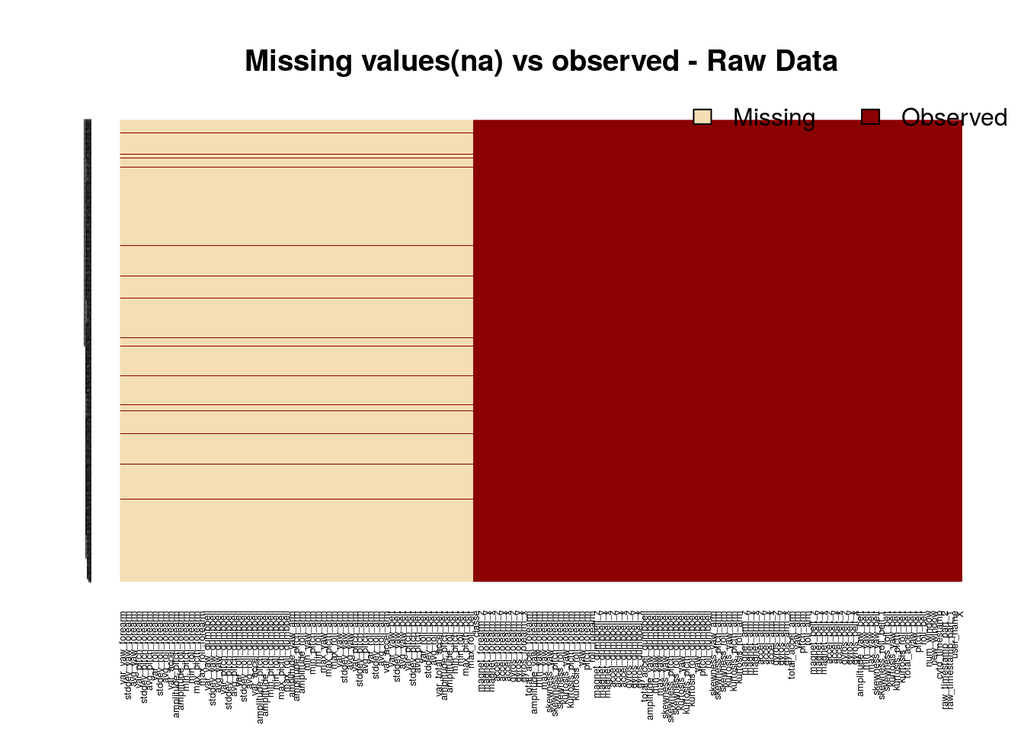

# 4 Data Preparation

Given the nature of the data, the primary preparation is to recognise the various NA values and then assess the usefulness of the columns containing NAs.

For this pupose the following values are converted to NA

- “NA”
- “”
- “#DIV/0!”

After transformation, any column containing more than 95% NAs will be ignored for predictive purposes. Furthermore the first 7 columns appear to relate to the subject and experiment time of day so they will also be ignored for predictive purposes.

Following this data “cleanup” 52 columns are retained for the prediction model and 107 are discarded. The “classe” column (to be predicted) is also retained.

The updated Missing Values Map appears as follows, note that there are now few missing values.

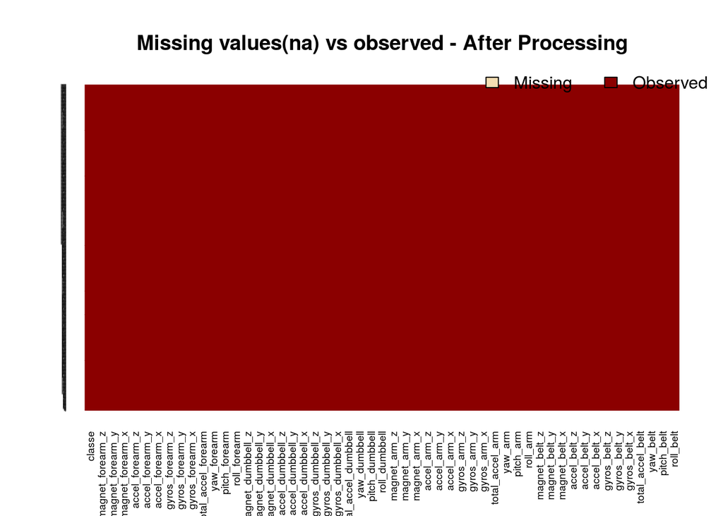

# 5 Model Construction (how the model was built)

Prior to finalising the model several approaches were considered -

- Classification Tree
- Random Forest
- Logistic Regression (General Linear Model)
- Boosting (Adaboost)
- Generalized Boosted Regression Modeling (GBM)
- Combine Random Forest and GBM (say)

The Random Forest and Boosting approaches were investigated as highly likely to produce useable models and requiring minimal data manipulation (eg. centering and scaling, co-linearity reduction).

Classification Tree was discarded as being less capable than Random Forest, GBM or Adaboost.  
Logistic Regression was discarded as it will require additional preparatory work with the data and is unlikely to out-perform the non-parametric approaches.  
The Model Ensemble approach was discarded as being unnecessary in this case as initial investigation of the selected models suggested very good performance ie. marginal benfit to ensembling.

Default settings are used for training of the models.

After training the models

| Model | Train OOB Error Rate | OOS Error Rate | Run Time (secs) |
| --- | --- | --- | --- |
| Boosting | 6.1804 % | 7.0178 % | 276.393 |
| GBM | NaN % | 3.6194 % | 1219.617 |
| Random Forest | 0.6988 % | 0.4928 % | 2946.298 |

On the basis of the above data we chose the Random Forest model (it has the lower Out Of Bag and Out Of Sample error rates) as our preferred approach and will use that to generate the final test set prediction.

For the Random Forest model, the relative importance of predictors is

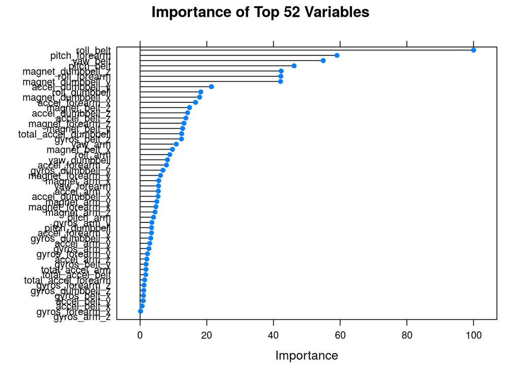

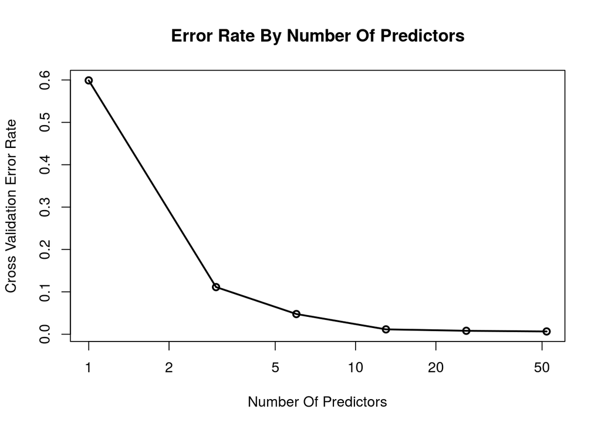

Generate a new model, based on the top 15 Predictors, by “importance”.

The predictors selected for use are -  
roll_belt, pitch_belt, yaw_belt, accel_belt_z, magnet_belt_z, roll_dumbbell, accel_dumbbell_y, accel_dumbbell_z, magnet_dumbbell_x, magnet_dumbbell_y, magnet_dumbbell_z, roll_forearm, pitch_forearm, accel_forearm_x, magnet_forearm_z

And the resulting error rates (Note second row) are

| Model | Train OOB Error Rate | OOS Error Rate | Run Time (secs) |
| --- | --- | --- | --- |
| Random Forest | 0.6988 % | 0.4928 % | 2946.298 |
| Refined Random Forest | 1.0774 % | 0.9686 % | 835.558 |

So our error rate has climbed a little but we have reduced the chance of overfitting.

# 6 Cross Validation (how cross validation was used)

Part of what a random forest does is bootstrap the data i.e., draw random samples with replacement from the original sample. In each instance, a model is fit to the data drawn. Then this model is applied to predict the data NOT drawn (the “out-of-bag” sample). This is a very smart trick to approximate the true expected out-of-sample error rate. The final model provides a “Confusion Matrix” which represents the outcome of this cross validation. Thus cross-validation is a design feature of the random forest method used to build the final model.

Additionally, in this exercise we have selected 70% of the original “Training” dataset to train the selected model with and reserved the other 30% as a cross-validation subset. This allows us to calculate an Out Of Sample error rate based on a sample completely independent of data used to train the model.

# 7 Summary Of Choices (architectural decisions)

**Data Exploration & Discard Columns**  
Any column with a high proportion of NAs (over 95 %) is ignored for the purposes of prediction. This assessment was performed after reclassifying some data as NA (ie. blank and “#DIV/0!” values in factor columns).

**Data Partitioning**  
Data was partitioned into -

- A random sample of 70% of the provided “training” data used for model training
- The remaining 30% of the originally provided “training” data to be used for model cross validation.

This allows final verification of the Out Of Sample error rate separately from the “Out Of The Bag” error rate.

**Pre-Processing**  
The proposed models are all resilient to unscaled predictors so data was neither centred nor scaled.

There was no need to use Principal Component Analysis to reduce the number of predictors as

- The number used was evaluated in a reasonable amount of time (about 1 hour on the development machine using a single core of the 3 available)
- The chosen models are not sensitive to interactions between predictors so there was no need to reduce interactions
- The result did not seem to be an overfit given the OOB and OOS error rates.

Therefore PCA was NOT undertaken.

**Model Choice**  
This is a Classification problem. The following model options were considered and DISCARDED -

- Logistic Regression (Generalised Linear Model)
- Decision Tree
- Boosted (Adaboost)
- Generalised Boosted Regression Modelling (GBM)
- Model Ensemble

The Random Forest model was selected as most appropriate. Run times were acceptable and the model itself performed admirably. The 20 final test cases were predicted perfectly and the OOB and OOS error rates were both low which inspires confidence in the quality of resulting predictions.

**Model Parameters**  
Default model parameters were used throughout on the basis that the default produced such a good outcome further tuning was not required.

**Predictor Selection**  
Predictors were evaluated for importance to (impact on) the model. The top 15 predictors (by importance) were selected ofr use in the final model.  
This process helps to avoid over-fitting. As a byproduct it also significantly reduces computational overhead.

**Performance**  
There is an opporunity to improve the computational performance of the Random Forest model -

- Using a “cluster” approach to enable the use of more CPU cores.
- Changing the model parameters to change the “method” to reduce the number of bootstrap iterations or number of variables sampled (mtry)
- Reducing the number of predictors eg. selecting via PCA or model importance.

# 8 Out Of Sample Error

The Refined Random Forest Out Of Bag error rate = 1.08 %.

The calculated Out Of Sample error rate = 0.97 %.

Out Of Sample Test Set - Confusion Matrix

|  | Accuracy | Kappa | AccuracyLower | AccuracyUpper | AccuracyNull | AccuracyPValue |
| --- | --- | --- | --- | --- | --- | --- |
| Value | 0.99031 | 0.98775 | 0.98747 | 0.99266 | 0.28445 | 0 |

Thus the Out Of Sample Error calculated from the test data confusion matrix is 0.97 % (1 - Accuracy) and the lower limit on the 95% confidence interval is 1.25 %

ie. we can be 95% confident that our out of sample error is lower than 1.25 %.

# 9 Final Prediction (predict 20 different test cases)

The final predictions produced from our model are -  
B, A, B, A, A, E, D, B, A, A, B, C, B, A, E, E, A, B, B, B  
which the Coursera software assessed as 100% correct!

# 10 References

http://groupware.les.inf.puc-rio.br/har#collaborators  
http://groupware.les.inf.puc-rio.br/public/papers/2012.Ugulino.WearableComputing.HAR.Classifier.RIBBON.pdf  
https://cran.r-project.org/web/packages/randomForest/randomForest.pdf  
https://rayli.net/blog/data/top-10-data-mining-algorithms-in-plain-r/

# 11 Appendix - Code

```r
# Define the necessary libraries
library(Amelia)  # Display missing values in dataframe
library(caret)    # For glm and Predict. GLM performs POORLY - don't use without lots of tuning
library(randomForest)
#library(rpart)   # Tree. Not a great performer
library(adabag)  # Adaboost. Performs ok-ish. At least 2 wrong (of 20)
#library(C50)     # C50 library for C5.0 algo (upmarket RF). Didn't perform so well
#library(rattle)  # Used to plot Trees
library(ggplot2)  # Plot functions
library(knitr)    # Layout functions
#
# Acquire the data and initialise libraries
strTrain_data_file <- "pml-training.csv"
strTrain_data_url <- "http://d396qusza40orc.cloudfront.net/predmachlearn/pml-training.csv"
strTest_data_file <- "pml-testing.csv"
strTest_data_url <- "http://d396qusza40orc.cloudfront.net/predmachlearn/pml-training.csv"
# setwd("/home/ubuntu/Downloads/coursera/data_science/08_practical_machine_learning/project_week04/")
# If necessary, download the datasets
if (!file.exists(strTrain_data_file)) {
  download.file(strTrain_data_url, destfile = strTrain_data_file)
}
if (!file.exists(strTest_data_file)) {
  download.file(strTest_data_url, destfile = strTest_data_file)
}
#
dfTrain <- read.csv(strTrain_data_file,header=TRUE)  # 19,622 obs, 160 cols
# dfTrain <- read.csv(strTrain_data_file,header=TRUE,
#            na.strings=c("","NA","#DIV/0!"))    # Converts rubbish data directly
#                                                # If I'd known at the time
dfTest <- read.csv(strTest_data_file,header=TRUE)  # 20 obs, 160 cols
# dfTest <- read.csv(strTest_data_file,header=TRUE,
#            na.strings=c("","NA","#DIV/0!"))    # Converts rubbish data directly
#                                                # If I'd known at the time
print("The Training dataset dimensions are:")
dim (dfTrain)
print("More detailed inspection of the Training dataset")
#str (dfTrain)    # Includes column names, many factors and numerics. Lots of NAs
str (dfTrain[,1:20])  # Review the first 20 columns (of 160)
summary(dfTrain[,1:20])  # More detailed review of the first 20 columns
#dim (dfTest)
#str (dfTest)     # Includes column names, many factors and numerics. Lots of NAs
# Display the missing values
missmap(dfTrain, main = "Missing values(na) vs observed - Raw Data", x.cex=0.4,y.cex=0.1)
#
# Have a look at the NAs in Train set, so many we should perhaps eliminate them.
# In most cases these columns are all NAs bar 400 or so (19,216 / 19,622)
strNames <- names(dfTrain)
# OK, set for data cleanup
booKeep <- rep(TRUE, length(strNames))
numFactor_levels <- rep(-1, length(strNames))
numNA_clip = 0.95  # 95% of 20,000 is about 19000
numDIV0_clip <- 0.49 # 40% of 20,000 is about 8,000
numLevels_clip = 2  # Need at least 5 "levels" for a valid factor variable
j <- 0
facNames <- rep("",2)
dfTrain_temp <- dfTrain
for (i in 1:length(strNames)) {
    if (is.factor(dfTrain_temp[,i])) {
        numFactor_levels[i] <- length(levels(dfTrain_temp[,i]))
    }
    if (sum(is.na(dfTrain_temp[,i])) / length(dfTrain_temp[,i]) > numNA_clip)  {
        booKeep[i] <- FALSE
    } else
    if (sum(dfTrain_temp[,i]=="#DIV/0!")>0 | sum(dfTrain_temp[,i]=="")>0) {
        booDivs <- dfTrain_temp[,i]=="#DIV/0!" | dfTrain_temp[,i]==""
        dfTrain_temp[booDivs,i] <- NA
        dfTrain_temp[,i] <- as.numeric(as.character(dfTrain_temp[,i]))
        if (sum(is.na(dfTrain_temp[,i])) / length(dfTrain_temp[,i]) > numNA_clip)  {
            booKeep[i] <- FALSE
        }
    }
}
booKeep[1:7] = FALSE  # The X variable (first in array) is a sequence number - ignore it
                      # and the other first 6 - identify person and timeframe only
#sum(booKeep) # Keep 53, Ignore 107 of the columns as being mostly useless ?

dfTrain_re <- dfTrain_temp[,booKeep]  # Use all but the useless columns
dfTest_re <- dfTest[,booKeep]  # Use all but the useless columns

missmap(dfTrain_re, main = "Missing values(na) vs observed - After Processing", x.cex=0.6,y.cex=0.1)
# We want to predict "classe" which is column 53
# Create a sampled Subset for training and out-of-sample error assessment
set.seed(3141)
numSample <- createDataPartition(dfTrain_re[,53], p = 0.70,list=FALSE)
#booSample <- sample(dfTrain_re,0.7,replace=FALSE)
dfTrain_re_train <- dfTrain_re[numSample,]
dfTrain_re_test <- dfTrain_re[-numSample,]
# THIS ADABOOST PRETTY LIGHT ON CPU ! Takes about 5 mins
set.seed(3141)
mdlAdab_time <- system.time(mdlAdab <- boosting(classe~., data=dfTrain_re_train))
prdAdab_train_train <- predict(mdlAdab,newdata=dfTrain_re_train)
prdAdab_train_test <- predict(mdlAdab,newdata=dfTrain_re_test)
prdAdab_test <- predict(mdlAdab,newdata=dfTest_re)
#   [1] "B" "A" "B" "A" "A" "E" "D" "B" "A" "A" "C" "C" "B" "A" "E" "E" "A" "B" "A" "B"
#       2 wrong - 11 and 19
#        1   2   3   4   5   6   7   8   9  10  11  12  13  14  15  16  17  18  19  20
#   [1]  B   A   B   A   A   E   D   B   A   A   B   C   B   A   E   E   A   B   B  B
numAdab_Miss_train_rate <- 1 - sum(diag(prdAdab_train_train$confusion[,1:5])) /
    sum(prdAdab_train_train$confusion[,1:5]) # = 0.05954721 OOB error rate
numAdab_Miss_test_rate <- 1 - sum(diag(prdAdab_train_test$confusion[,1:5])) /
    sum(prdAdab_train_test$confusion[,1:5]) # = 0.05879354 OOS error rate
#
set.seed(3141)
mdlGbm_time <- system.time(mdlGbm <- train(classe~.,data=dfTrain_re_train,method="gbm",
             verbose=FALSE)) #,
#            bag.fraction=0.7,cv.folds=5,verbose=FALSE))  # Doesn't work for some reason
# About 20 minutes to run (1290 secs)
# mdlGbm_gbm_time <- system.time(mdlGbm_gbm <- #
#       gbm(classe~.,data=dfTrain_re_train,cv.folds=3,distribution="multinomial",bag.fraction=0.7))
#  About 14 seconds run time
prdGbm_train_train <- predict(mdlGbm, newdata=dfTrain_re_train)
prdGbm_train_test <- predict(mdlGbm, newdata=dfTrain_re_test)
prdGbm_test <- predict(mdlGbm, newdata=dfTest_re)
#   [1] B A B A A E D B A  A  B  C  B  A  E  E  A  B  B  B  # All correct
#       1 2 3 4 5 6 7 8 9 10 11 12 13 14 15 16 17 18 19 20
#   [1] B A B A A E D B A  A  B  C  B  A  E  E  A  B  B  B  # ALL Correct - PERFECT (using 100% of train set)
#
# confusionMatrix(prdGbm_train_test, dfTrain_re_test$classe)
# confusionMatrix(prdGbm_train_test, dfTrain_re_test$classe)$overall  # Accuracy ratings
# confusionMatrix(prdGbm_train_train, dfTrain_re_train$classe)
numGbm_Miss_train <- sum(as.character(prdGbm_train_train) != as.character(dfTrain_re_train$classe))
numGbm_Miss_train_rate <- sum(numGbm_Miss_train) / length(dfTrain_re_train$classe) # =
numGbm_Miss_test <- sum(as.character(prdGbm_train_test) != as.character(dfTrain_re_test$classe))
numGbm_Miss_test_rate <- sum(numGbm_Miss_test) / length(dfTrain_re_test$classe) # = 0.007476636 OOS rate
numGbm_Miss_train_rate_mdl <- 1 - sum(diag(mdlGbm$finalModel$confusion[,1:5])) /
     sum(mdlGbm$finalModel$confusion[,1:5])  # OOB error rate = 0.007134018
# Separated out for operational management - this takes a while (approx 60 mins)
set.seed(3141)
mdlRf_time <- system.time(mdlRf <- train(classe~., data=dfTrain_re_train, method = "rf"))
prdRf_train_train <- predict(mdlRf,newdata=dfTrain_re_train)
    # Use to find OOB Error Rate (out of bag)
prdRf_train_test <- predict(mdlRf,newdata=dfTrain_re_test)
    # Use to find OOS Error Rate (out of sample)
prdRf_test <- predict(mdlRf,newdata=dfTest_re)   # To answer Quiz questions
```

```
#> prdRf_test
```

```r
#       1 2 3 4 5 6 7 8 9 10 11 12 13 14 15 16 17 18 19 20
#   [1] B A B A A E D B A  A  B  C  B  A  E  E  A  B  B  B
    # ALL Correct - PERFECT (using 100% of train set)
#   [1] B A B A A E D B A  A  B  C  B  A  E  E  A  B  B  B
    # Using 70% of Train set only, 100% accurate again !
#mdlRf$finalModel # Look at model basics
#varImp(mdlRf)  # Which variables are useful ?
#
numRf_Miss_train <- sum(as.character(prdRf_train_train) != as.character(dfTrain_re_train$classe))
numRf_Miss_train_rate <- sum(numRf_Miss_train) / length(dfTrain_re_train$classe) # =
numRf_Miss_test <- sum(as.character(prdRf_train_test) != as.character(dfTrain_re_test$classe))
numRf_Miss_test_rate <- sum(numRf_Miss_test) / length(dfTrain_re_test$classe) # = 0.007476636 OOS rate
numRf_Miss_train_rate_mdl <- 1 - sum(diag(mdlRf$finalModel$confusion[,1:5])) /
     sum(mdlRf$finalModel$confusion[,1:5])  # OOB error rate = 0.007134018
# Generate the Predictor Cross Validation data for tuning the RF model
set.seed(3141)
rfcvRf <- rfcv(dfTrain_re_train[,-53],dfTrain_re_train[,53])
#par(mfrow = c(1, 2)) # 1 x 2 pictures on one plot
plot(varImp(mdlRf), main = "Importance of Top 52 Variables", top = 52)
#with(rfcvRf, plot(n.var, error.cv, log="x", type="o", lwd=2,
plot(rfcvRf$n.var, rfcvRf$error.cv, log="x", type="o", lwd=2,
     xlab="Number Of Predictors",
     ylab="Cross Validation Error Rate",
     main="Error Rate By Number Of Predictors")  # Nice plot, 15 predictors optimum
strCols_fit <- rownames(varImp(mdlRf)$importance)[1:52]
                    # Importance > (13 => 15, 9 => 20, 6 => 25, 5 => 30)
booRow_names <- (varImp(mdlRf)$importance>13)[1:52]  # Set based on Importance and number rows reqd
strCols_fit <- c(strCols_fit[booRow_names],"classe")
set.seed(3141)
mdlRf2_time <- system.time(mdlRf2 <- train(classe~.,
    data=dfTrain_re_train[,strCols_fit], method = "rf"))
prdRf2_train_train <- predict(mdlRf2,newdata=dfTrain_re_train[,strCols_fit])
prdRf2_train_test <- predict(mdlRf2,newdata=dfTrain_re_test[,strCols_fit])
                            # Use to find OOS Error Rate (out of sample)
prdRf2_test <- predict(mdlRf2,newdata=dfTest_re[,strCols_fit[1:length(strCols_fit)-1]])
                            # To answer Quiz questions
numRf2_Miss_train <- sum(as.character(prdRf2_train_train) != as.character(dfTrain_re_train$classe))
numRf2_Miss_train_rate <- sum(numRf2_Miss_train) / length(dfTrain_re_train$classe) # =
numRf2_Miss_test <- sum(as.character(prdRf2_train_test) != as.character(dfTrain_re_test$classe))
numRf2_Miss_test_rate <- sum(numRf2_Miss_test) / length(dfTrain_re_test$classe) # = 0.007476636 OOS rate
numRf2_Miss_train_rate_mdl <- 1 - sum(diag(mdlRf2$finalModel$confusion[,1:5])) /
     sum(mdlRf2$finalModel$confusion[,1:5])  # OOB error rate = 0.007134018
#   [1] B A B A A E D B A  A  B  C  B  A  E  E  A  B  B  B
                                    # All correct at 30 preds (Imp >5) in 1716 Secs (30 mins)
#   [1] B A B A A E D B A  A  B  C  B  A  E  E  A  B  B  B
                                    # All correct at 15 preds (Imp >13) in 970 Secs (15 mins)
#       1 2 3 4 5 6 7 8 9 10 11 12 13 14 15 16 17 18 19 20
#   [1] B A B A A E D B A  A  B  C  B  A  E  E  A  B  B  B
                                    # ALL Correct - PERFECT (using 100% of train set)
#
# confusionMatrix(mdlRf2)
# confusionMatrix(prdRf2_train_train2, dfTrain_re_train$classe)  # Good info
# confusionMatrix(prdRf2_train_test2, dfTrain_re_test$classe)  # Good info
# confusionMatrix(prdRf2_train_test2, dfTrain_re_test$classe)$overall  # [1] = accuracy [3] = CI Low [4] = Accuracy High
# confusionMatrix(prdRf2_train_test2, dfTrain_re_test$classe)$overall[c(1,3,4)] # Accuracy + CI


## Process VIF data into a nice table
  cfm_prdRf2_train_test <- as.data.frame(confusionMatrix(prdRf2_train_test,
                                dfTrain_re_test$classe)$overall[1:6])
  cfm_prdRf2_train_test$rowname <- row.names(cfm_prdRf2_train_test)
  names(cfm_prdRf2_train_test) <- c("Value","rowname")
  cfm_prdRf2_train_test$rowname <- NULL
  kable(t(cfm_prdRf2_train_test),digits=5,caption="Out Of Sample Test Set - Confusion Matrix")
```